# 🌊 Fishing area analysis

Source: [`vignettes/articles/fishing-areas.Rmd`](https://github.com/Linbojun99/faofishingreport/blob/main/vignettes/articles/fishing-areas.Rmd)

📦 **Data**: [FAO Global Capture Production](https://www.fao.org/fishery/collection/capture/en), release **2026.1.0** (published by FAO on 2026-03-30; catches 1950–2024), downloaded from Capture_2026.1.0.zip. Licence [CC BY 4.0](https://creativecommons.org/licenses/by/4.0/). `fao_data_info()` shows the release you use and how to cite it.

`fao_areas()` and `fishing_area_map()` show the FAO major fishing areas and their subareas; the three other fishing area functions describe one area. The examples use the **Northeast Atlantic (area 27)**; the last section shows the same analysis for the **Northwest Atlantic (area 21)**.

## 🗺️ The FAO major fishing areas

The FAO major fishing areas for statistical purposes are defined by the Coordinating Working Party on Fishery Statistics (CWP): 19 marine areas, and the inland waters of each continent. `fao_areas()` lists them with their catch in the last year of the data and the link to the official FAO map of each area, and saves a world map of the marine areas labelled with their codes:

```r
areas <- fao_areas()
```

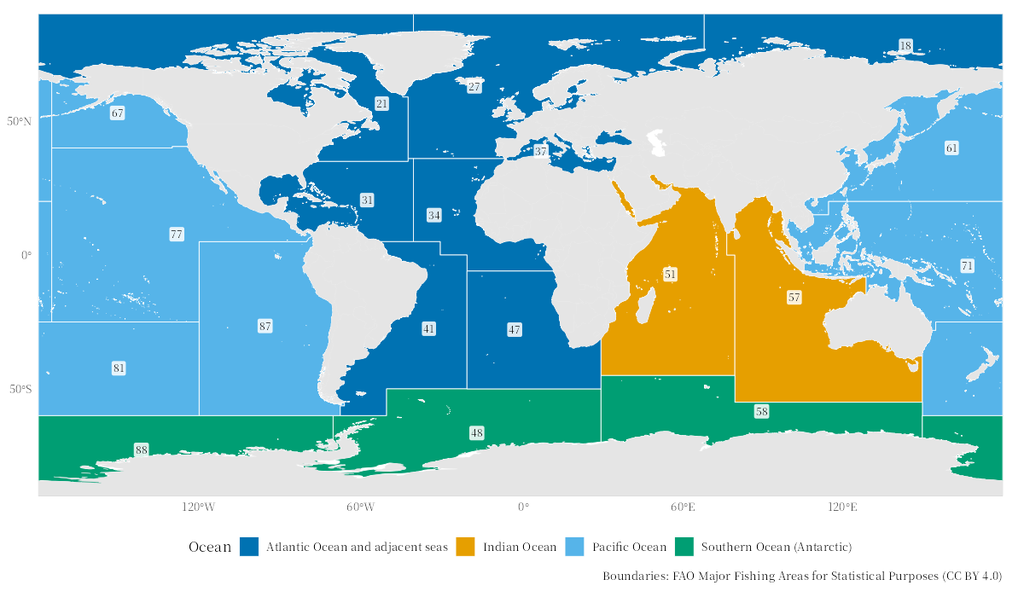

```r
show_table(areas[order(-areas$catch_last_year), c("area_code", "name_en", "type", "ocean", "catch_last_year", "share_pct")],
           n = 30, digits = 1)
```

|  | area_code | name_en | type | ocean | catch_last_year | share_pct |
| --- | --- | --- | --- | --- | --- | --- |
| 21 | 61 | Pacific, Northwest | marine | Pacific Ocean | 19067991.408 | 20.5 |
| 23 | 71 | Pacific, Western Central | marine | Pacific Ocean | 14105189.055 | 15.1 |
| 26 | 87 | Pacific, Southeast | marine | Pacific Ocean | 9453525.210 | 10.1 |
| 11 | 27 | Atlantic, Northeast | marine | Atlantic Ocean and adjacent seas | 7842194.162 | 8.4 |
| 4 | 04 | Asia - Inland waters | inland | NA | 7785533.070 | 8.4 |
| 19 | 57 | Indian Ocean, Eastern | marine | Indian Ocean | 6401679.921 | 6.9 |
| 18 | 51 | Indian Ocean, Western | marine | Indian Ocean | 6223934.387 | 6.7 |
| 13 | 34 | Atlantic, Eastern Central | marine | Atlantic Ocean and adjacent seas | 5099475.194 | 5.5 |
| 1 | 01 | Africa - Inland waters | inland | NA | 3656926.956 | 3.9 |
| 22 | 67 | Pacific, Northeast | marine | Pacific Ocean | 2551440.501 | 2.7 |
| 24 | 77 | Pacific, Eastern Central | marine | Pacific Ocean | 2349505.260 | 2.5 |
| 15 | 41 | Atlantic, Southwest | marine | Atlantic Ocean and adjacent seas | 1970436.942 | 2.1 |
| 16 | 47 | Atlantic, Southeast | marine | Atlantic Ocean and adjacent seas | 1475796.444 | 1.6 |
| 10 | 21 | Atlantic, Northwest | marine | Atlantic Ocean and adjacent seas | 1407262.000 | 1.5 |
| 12 | 31 | Atlantic, Western Central | marine | Atlantic Ocean and adjacent seas | 1077647.351 | 1.2 |
| 14 | 37 | Mediterranean and Black Sea | marine | Atlantic Ocean and adjacent seas | 1026111.034 | 1.1 |
| 17 | 48 | Atlantic, Antarctic | marine | Southern Ocean (Antarctic) | 466706.916 | 0.5 |
| 5 | 05 | Europe - Inland waters | inland | NA | 386122.976 | 0.4 |
| 25 | 81 | Pacific, Southwest | marine | Pacific Ocean | 381352.879 | 0.4 |
| 3 | 03 | America, South - Inland waters | inland | NA | 337398.156 | 0.4 |
| 2 | 02 | America, North - Inland waters | inland | NA | 117613.045 | 0.1 |
| 6 | 06 | Oceania - Inland waters | inland | NA | 20521.568 | 0.0 |
| 9 | 18 | Arctic Sea | marine | Atlantic Ocean and adjacent seas | 16604.000 | 0.0 |
| 20 | 58 | Indian Ocean, Antarctic | marine | Southern Ocean (Antarctic) | 10861.059 | 0.0 |
| 27 | 88 | Pacific, Antarctic | marine | Southern Ocean (Antarctic) | 2665.606 | 0.0 |
| 7 | 07 | Former USSR area - Inland waters | inland | NA | NA | NA |
| 8 | 08 | Antarctica - Inland waters | inland | NA | NA | NA |

Use these names (e.g. `"Atlantic, Northwest"`) or codes in the other functions. The official FAO maps (column `fao_map`) are the maps of the [FAO fishing area maps](https://www.fao.org/fishery/docs/maps/Default.htm) page; the package links to them.

## 🧭 `fishing_area_map()`: an area and its subareas

Large areas are divided into subareas, divisions and subdivisions; in the Northeast Atlantic they are the ICES areas, from 27.1 (Barents Sea) to 27.14 (East Greenland). `fishing_area_map()` maps one marine area with these units, labelled with their codes, from the boundaries bundled with the package (FAO 2024). When the ggOceanMaps package (Vihtakari 2026) is installed, the map is drawn on its bathymetric base map, with the depth of the ETOPO 2022 relief model (NOAA NCEI 2022) bundled with ggOceanMaps; areas reaching beyond 60° of latitude, such as area 27, are drawn in a polar stereographic projection. Without ggOceanMaps, the land of Natural Earth is drawn in a Lambert azimuthal equal-area projection centred on the area.

```r
ne_atlantic <- fishing_area_map(27)
```

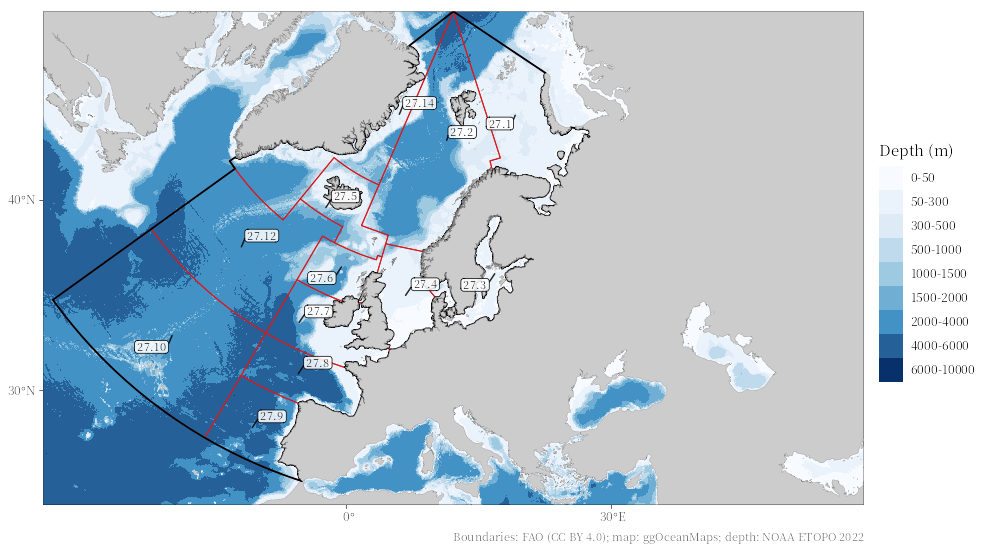

```r
show_table(ne_atlantic$units, n = 20)
```

| code | level | name_en |
| --- | --- | --- |
| 27.1 | subarea | Barents Sea (Subarea 27.1) |
| 27.2 | subarea | Norwegian Sea, Spitzbergen, and Bear Island (Subarea 27.2) |
| 27.3 | subarea | Skagerrak, Kattegat, Sound, Belt Sea, and Baltic Sea (Subarea 27.3) |
| 27.4 | subarea | North Sea (Subarea 27.4) |
| 27.5 | subarea | Iceland and Faroes Grounds (Subarea 27.5) |
| 27.6 | subarea | Rockall, Northwest Coast of Scotland and North Ireland (Subarea 27.6) |
| 27.7 | subarea | Irish Sea, West of Ireland, Porcupine Bank, Eastern and Western English Channel, etc (Subarea 27.7) |
| 27.8 | subarea | Bay of Biscay (Subarea 27.8) |
| 27.9 | subarea | Portuguese Waters (Subarea 27.9) |
| 27.10 | subarea | Azores Grounds and Northeast Atlantic South (Subarea 27.10) |
| 27.12 | subarea | North of Azores (Subarea 27.12) |
| 27.14 | subarea | East Greenland (Subarea 27.14) |

```r
ne_atlantic$fao_map      # the official FAO map of the area
```

```
#> [1] "https://www.fao.org/fishery/docs/maps/fig_h2_27_0.gif"
```

The sources of the map are in `ne_atlantic$sources`, to cite with it:

```r
show_table(ne_atlantic$sources)
```

| layer | reference | url |
| --- | --- | --- |
| boundaries | FAO (2024). FAO Major Fishing Areas for Statistical Purposes. Licence: CC-BY 4.0. | https://www.fao.org/fishery/geonetwork?uuid=ac02a460-da52-11dc-9d70-0017f293bd28 |
| base map | Vihtakari, M. (2026). ggOceanMaps: Plot Data on Oceanographic Maps using ‘ggplot2’. R package version 3.0.0. doi:10.32614/CRAN.package.ggOceanMaps | https://github.com/MikkoVihtakari/ggOceanMaps |
| land | Natural Earth. 1:10m Land and Minor Islands (public domain), as bundled with ggOceanMaps. | https://www.naturalearthdata.com/downloads/10m-physical-vectors/ |
| depth | NOAA National Centers for Environmental Information (2022). ETOPO 2022 15 Arc-Second Global Relief Model. doi:10.25921/fd45-gt74 | https://doi.org/10.25921/fd45-gt74 |

The divisions, here without depth:

```r
fishing_area_map(27, level = "division", bathymetry = FALSE)
```

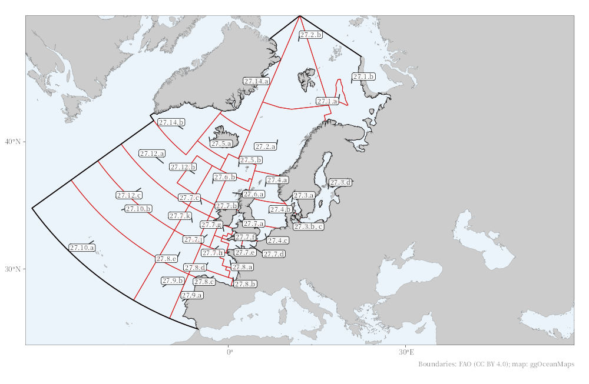

All arguments of `fishing_area_map()`:

| Argument | Meaning | Default |
| --- | --- | --- |
| `area` | FAO major marine fishing area: code (e.g. `27`) or English name |  |
| `level` | Units drawn inside the area: `"subarea"`, `"division"`, `"subdivision"` or `"none"` (outline only) | `"subarea"` |
| `bathymetry` | Show the depth (ggOceanMaps only) | `TRUE` |
| `labels` | Label the units with their codes | `TRUE` |
| `engine` | `"auto"` (ggOceanMaps when installed, else `"sf"`), `"ggOceanMaps"` or `"sf"` | `"auto"` |
| `plot` | Save the map in `figures/png/area/` | `TRUE` |
| `table` | Save the table of units in `tables/` | `TRUE` |
| `lang` | Language of the map text: `"en"`, `"zh"` or `"both"` | `NULL`: the language of `fao_settings()` |
| `pptx` | Also save the map as an editable PowerPoint file | `FALSE`, or `pptx` of `fao_settings()` |
| `plot_show` | Also draw each chart in the plot window (e.g. the Plots pane of RStudio) as it is saved | `FALSE`, or `plot_show` of `fao_settings()` |

## 1️⃣ `fishing_area_data()`: catch of the area

```r
FAO27 <- fishing_area_data("Atlantic, Northeast")
```

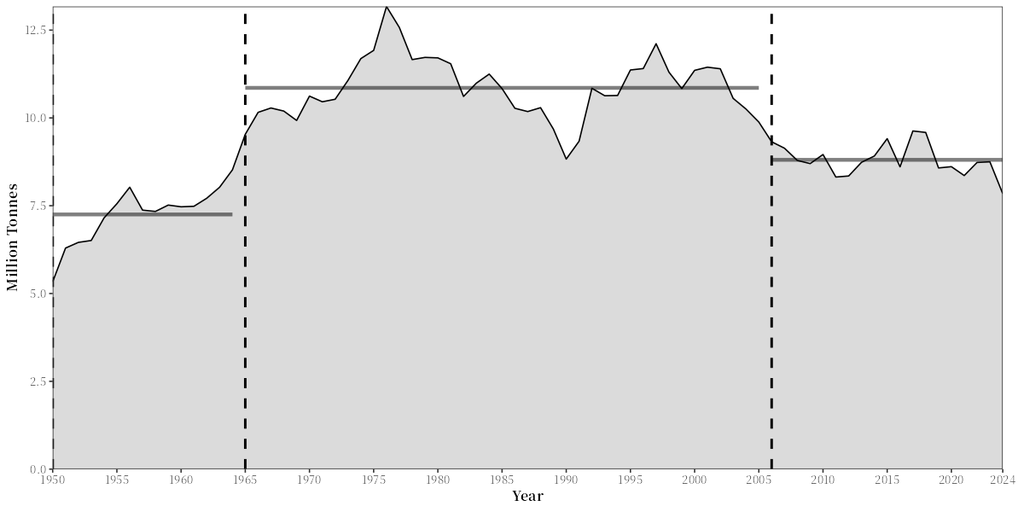

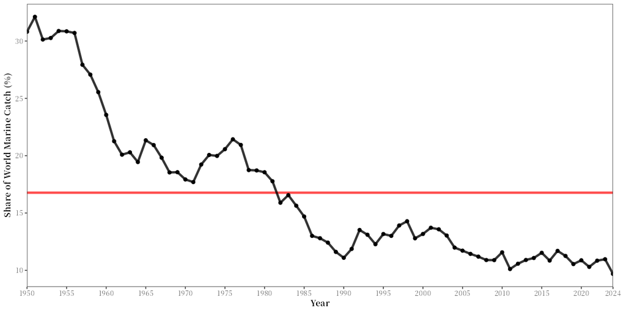

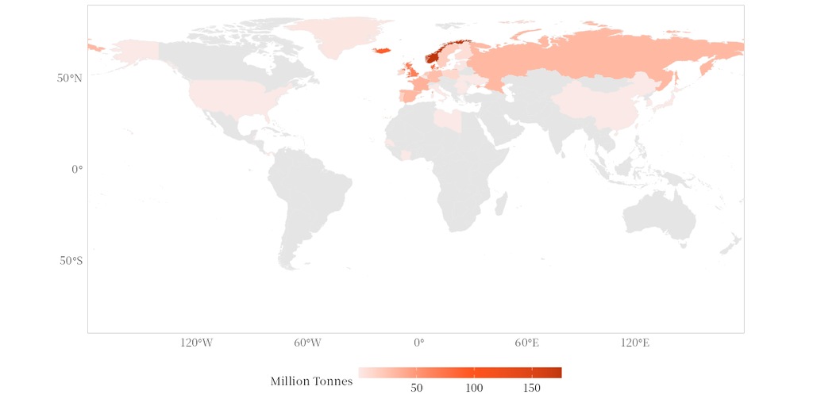

It saves three charts in `figures/png/`:

[output not shown]

and returns a list:

| Element | Content |
| --- | --- |
| `area_data` | Catch records of the area (all eight columns of the data): the input of the other functions |
| `coefs_data` | Periods between breakpoints of the total catch: `start_year`, `end_year` and `intercept` (mean catch of the period, in tonnes) |
| `act_world_map` | The map data, an sf object with the total catch of each country (`NULL` with `plot = FALSE`) |

```r
FAO27$coefs_data
```

```
#> # A tibble: 3 × 3
#>   start_year end_year intercept
#>        <int>    <int>     <dbl>
#> 1       1950     1964  7251706.
#> 2       1965     2005 10855609.
#> 3       2006     2024  8806378.
```

### Options

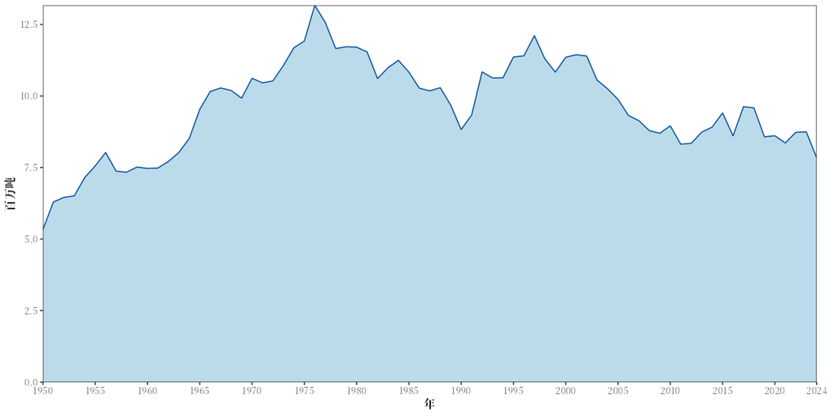

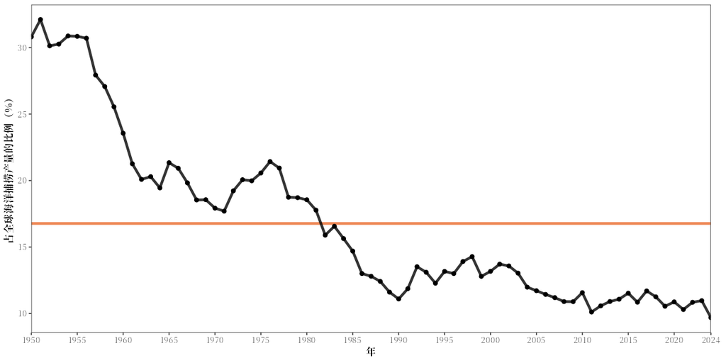

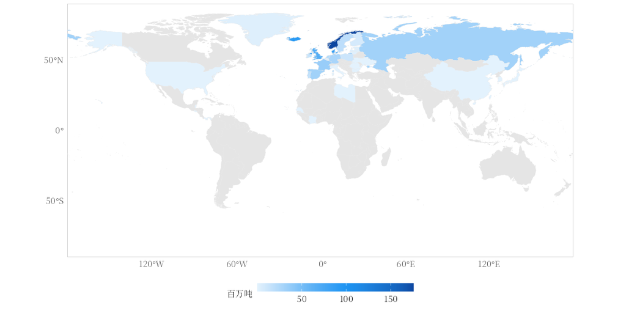

```r
fishing_area_data(
  "Atlantic, Northeast",
  timeseries_analysis = FALSE,          # no breakpoints
  area_color1 = "#9ecae1",              # fill of the catch area
  area_color2 = "#08519c",              # its outline
  hline_color = "#e6550d",              # average line of the share chart
  fill_scale = "blue",                  # palette of the map
  lang = "zh"                           # Chinese chart text
)
```

All arguments of `fishing_area_data()`:

| Argument | Meaning | Default |
| --- | --- | --- |
| `area_name` | FAO major fishing area, as named in the data (table above) |  |
| `plot` | Save the three charts; `FALSE` only returns the data | `TRUE` |
| `timeseries_analysis` | Draw the breakpoints and the mean catch of each period on the total catch chart (`coefs_data` is returned either way) | `TRUE` |
| `area_color1` | Fill colour of the total catch | `"grey80"` |
| `area_alpha` | Transparency of that fill (0 transparent to 1 opaque) | `0.7` |
| `area_color2` | Outline colour of the total catch | `"black"` |
| `line_color` | Colour of the line of the share chart | `"black"` |
| `line_alpha` | Transparency of that line | `0.8` |
| `line_linewidth` | Width of that line | `1.5` |
| `point_size` | Size of the points of the share chart | `2` |
| `hline_color` | Colour of the average line of the share chart | `"red"` |
| `hline_alpha` | Transparency of the average line | `0.7` |
| `hline_linewidth` | Width of the average line | `1.5` |
| `axis_text_size` | Size of the axis labels of the share chart, and of the axis titles of the total catch chart | `10` |
| `axis_text_face` | Font face of the axis titles of the total catch chart: `"plain"`, `"bold"`, `"italic"` or `"bold.italic"` | `"plain"` |
| `axis_title_size` | Size of the axis titles of the share chart | `12` |
| `axis_title_face` | Font face of the axis titles of the share chart and the map | `"bold"` |
| `strip_text_size`, `strip_text_face` | Size and font face of panel titles; the charts of this function have no panels, so they have no visible effect | `12`, `"bold"` |
| `polygon_color` | Colour of the country borders on the map | `"grey90"` |
| `fill_scale` | Palette of the map, any choice of `map_palette` in `fao_settings()` (e.g. `"blue"`, `"YlOrRd"`, `"viridis"` or a vector of colours) | `NULL`: `map_palette` of `fao_settings()` (`"deep-orange"`) |
| `axis_title_size_map` | Size of the axis titles of the map | `14` |
| `axis_text_size_map` | Size of the axis labels (longitudes and latitudes) of the map | `12` |
| `legend_text_size_map` | Size of the legend text of the map | `12` |
| `ZH` | Older way of asking for Chinese: `TRUE` is `lang = "zh"` | `FALSE` |
| `lang` | Language of the chart text: `"en"`, `"zh"` or `"both"` | `NULL`: `"zh"` if `ZH = TRUE`, else the language of `fao_settings()` |
| `data_version` | FAO release: `"latest"` (newest available), `"bundled"` or a release such as `"2026.1.0"` (see 💾 FAO data) | `"latest"` |
| `pptx` | Also save the charts as editable PowerPoint files in `figures/pptx/` | `FALSE`, or `pptx` of `fao_settings()` |
| `plot_show` | Also draw each chart in the plot window (e.g. the Plots pane of RStudio) as it is saved | `FALSE`, or `plot_show` of `fao_settings()` |

## 2️⃣ `fishing_area_species()`: main species

```r
species <- fishing_area_species(FAO27$area_data, rank_range = 1:10)
```

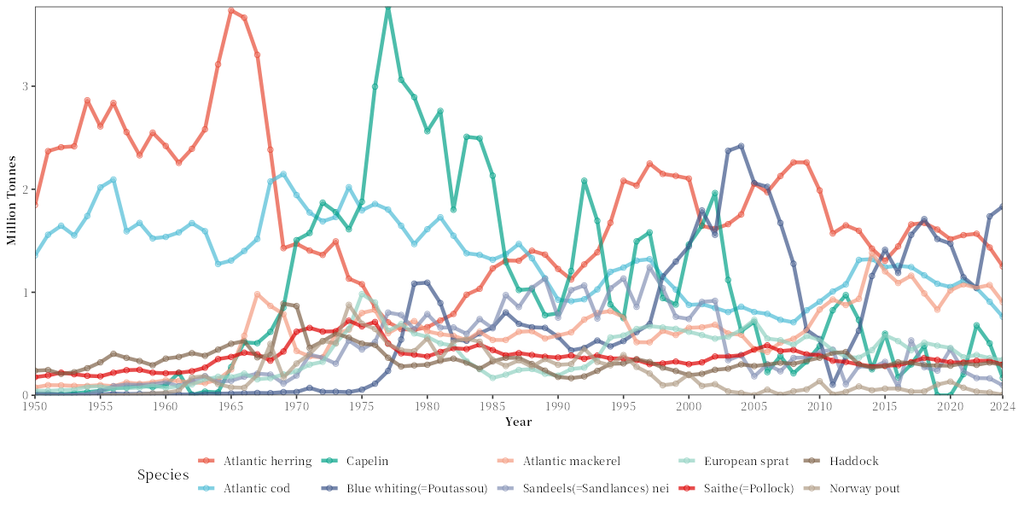

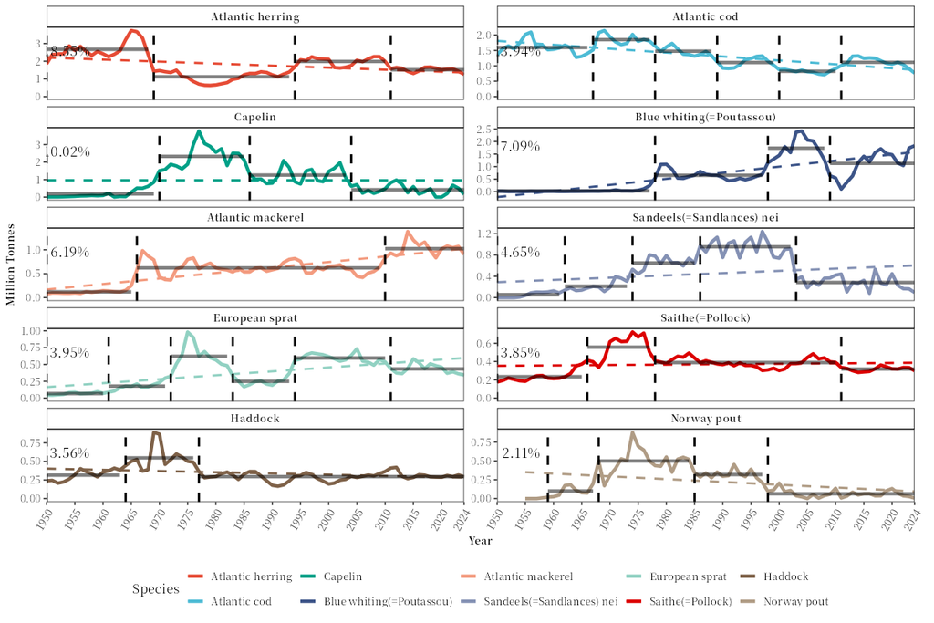

[output not shown]

The function returns a list:

| Element | Content |
| --- | --- |
| `area_species` | Catch of every species item by year |
| `area_species_ranked` | Catch by year of the selected species, with their total catch and share |
| `area_species_ranked_total` | The selected species: total catch over all years (`Total_Tonnes`) and share of the area’s catch (`Percentage`) |
| `coefs_data` | Breakpoints of each species: `start_year`, `end_year` and `intercept` (mean catch of the period, in tonnes) |

```r
show_table(species$area_species_ranked_total)
```

| ASFIS.species..Name. | Total_Tonnes | Percentage | Rank_Tonnes |
| --- | --- | --- | --- |
| Atlantic herring | 133,779,008 | 18.55 | 133,779,008 |
| Atlantic cod | 100,515,875 | 13.94 | 100,515,875 |
| Capelin | 72,254,558 | 10.02 | 72,254,558 |
| Blue whiting(=Poutassou) | 51,097,741 | 7.09 | 51,097,741 |
| Atlantic mackerel | 44,615,940 | 6.19 | 44,615,940 |
| Sandeels(=Sandlances) nei | 33,532,765 | 4.65 | 33,532,765 |
| European sprat | 28,491,530 | 3.95 | 28,491,530 |
| Saithe(=Pollock) | 27,734,472 | 3.85 | 27,734,472 |
| Haddock | 25,693,597 | 3.56 | 25,693,597 |
| Norway pout | 15,252,882 | 2.11 | 15,252,882 |

It also saves two tables in `tables/`: `species_ranked_table.csv` (average catch per decade, catch in each of the last five years, catch and share in the last year) and `species_coefs_data.csv` (the breakpoints).

```r
show_table(read.csv("tables/species_ranked_table.csv", fileEncoding = "UTF-8-BOM", check.names = FALSE), n = 5, digits = 0)
```

| ASFIS.species..Name. | 1950s | 1960s | 1970s | 1980s | 1990s | 2000s | 2010s | 2020s | 2020 | 2021 | 2022 | 2023 | 2024 | total_2024_production | percentage_of_total_2024 |
| --- | --- | --- | --- | --- | --- | --- | --- | --- | --- | --- | --- | --- | --- | --- | --- |
| Atlantic cod | 1,675,240 | 1,610,620 | 1,772,437 | 1,424,846 | 1,104,442 | 814,172 | 1,162,071 | 975,521 | 1,051,293 | 1,116,132 | 1,039,707 | 908,068 | 762,408 | 762,408 | 10 |
| Atlantic herring | 2,478,450 | 2,737,960 | 1,078,316 | 1,080,178 | 1,732,866 | 1,945,565 | 1,592,207 | 1,464,718 | 1,514,865 | 1,554,649 | 1,568,174 | 1,435,049 | 1,250,851 | 1,250,851 | 16 |
| Atlantic mackerel | 100,330 | 414,570 | 603,160 | 580,576 | 654,196 | 574,634 | 1,022,817 | 1,022,622 | 1,018,792 | 1,076,697 | 1,043,653 | 1,069,949 | 904,017 | 904,017 | 12 |
| Blue whiting(=Poutassou) | 12,680 | 17,740 | 223,187 | 712,974 | 675,005 | 1,725,821 | 1,019,466 | 1,445,802 | 1,472,561 | 1,145,203 | 1,041,463 | 1,737,135 | 1,832,649 | 1,832,649 | 23 |
| Capelin | 43,550 | 314,260 | 2,294,263 | 1,838,143 | 1,230,845 | 867,671 | 480,992 | 311,462 | 57 | 204,767 | 679,198 | 504,595 | 168,693 | 168,693 | 2 |

### Options

- **`rank_range`** lists the ranks shown: `11:20` shows the next ten species, `c(5, 6)` the fifth and the sixth.
- **`timeseries_analysis = FALSE`** replaces the breakpoints by a smooth curve (`smooth_method`, default `"loess"`).
- **`h_value`** is the minimum length of a period between breakpoints: a fraction of the series (default `0.15`) or a number of years (e.g. `5`). Larger values give fewer breakpoints; species with too short a series are skipped with a message.

```r
fishing_area_species(FAO27$area_data, rank_range = 11:20, h_value = 5, lang = "both")
```

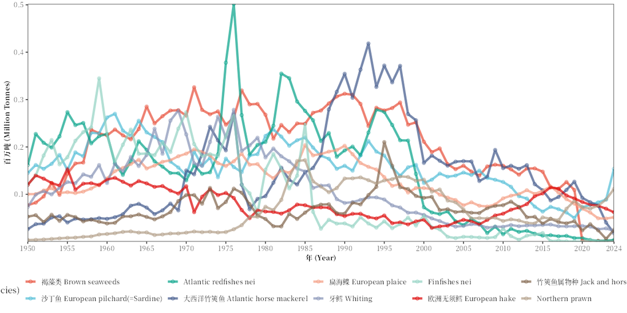

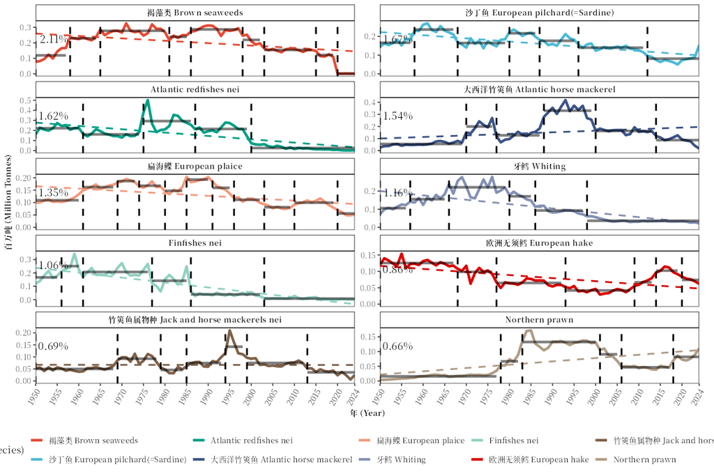

All arguments of `fishing_area_species()`. “Time series chart” is `area_species.png`, “panel chart” is `area_species_wrap.png`; the panel chart with breakpoints has fixed line widths, text sizes and two columns, and only the `text_*` arguments change it.

| Argument | Meaning | Default |
| --- | --- | --- |
| `area_data` | Catch data of an area: `fishing_area_data()$area_data` or any subset of `load_fao_data()` |  |
| `rank_range` | Ranks of the species shown, by total catch over all years: `1:10` the ten largest, `11:20` the next ten, `c(5, 6)` the fifth and the sixth | `1:10` |
| `plot` | Save the charts | `TRUE` |
| `table` | Save the two tables in `tables/` | `TRUE` |
| `timeseries_analysis` | `TRUE`: panel chart with linear trend and breakpoints; `FALSE`: panel chart with a smooth curve | `TRUE` |
| `h_value` | Minimum length of a period between breakpoints: a fraction of the series or a number of years (the `h` of `strucchange::breakpoints()`) | `0.15` |
| `line_width` | Width of the lines of the time series chart | `1.5` |
| `line_alpha` | Transparency of the lines of the time series chart and of the panel chart without breakpoints | `0.7` |
| `line_linewidth` | Width of the lines of the panel chart without breakpoints | `1.5` |
| `point_size` | Size of the points of the time series chart and of the panel chart without breakpoints | `1.8` |
| `point_alpha` | Transparency of these points | `0.7` |
| `point_shape` | Shape of these points (R point symbol, e.g. `1` open circle, `16` filled circle) | `1` |
| `axis_text_size`, `axis_text_face` | Size and font face of the axis labels (time series chart; y axis of the panel chart without breakpoints) | `10`, `"plain"` |
| `axis_title_size`, `axis_title_face` | Size and font face of the axis titles (time series chart; panel chart without breakpoints) | `10`, `"bold"` |
| `strip_text_size`, `strip_text_face` | Size and font face of the panel titles of the panel chart without breakpoints | `10`, `"bold"` |
| `smooth_method` | Smoothing method of the curve in the panel chart without breakpoints, as in `ggplot2::geom_smooth()`: `"loess"`, `"lm"`, `"gam"`, … | `"loess"` |
| `smooth_linetype` | Line type of that curve: `"dashed"`, `"solid"`, `"dotted"`, … | `"dashed"` |
| `text_hjust`, `text_vjust` | Horizontal and vertical justification of the share label in each panel (it is anchored at 1957 and zero catch) | `0.9`, `-4` |
| `text_size`, `text_color` | Size and colour of the share label | `4.5`, `"black"` |
| `facet_ncol` | Number of columns of the panel chart without breakpoints | `2` |
| `ZH` | Older way of asking for Chinese: `TRUE` is `lang = "zh"` | `FALSE` |
| `lang` | Language of the chart text and names: `"en"`, `"zh"` or `"both"` | `NULL`: `"zh"` if `ZH = TRUE`, else the language of `fao_settings()` |
| `pptx` | Also save the charts as editable PowerPoint files in `figures/pptx/` | `FALSE`, or `pptx` of `fao_settings()` |
| `plot_show` | Also draw each chart in the plot window (e.g. the Plots pane of RStudio) as it is saved | `FALSE`, or `plot_show` of `fao_settings()` |

## 3️⃣ `fishing_area_country()`: main countries

```r
countries <- fishing_area_country(FAO27$area_data, rank_range = 1:10)
```

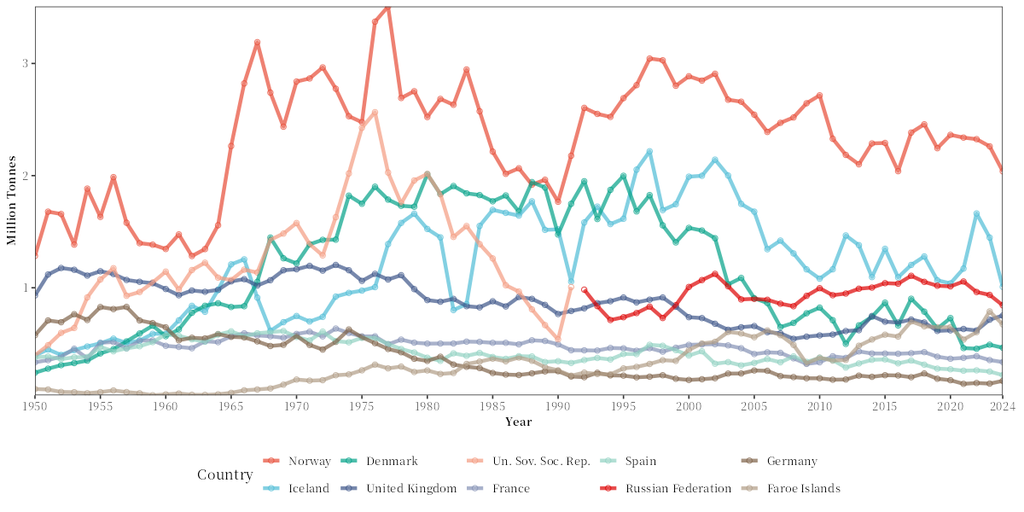

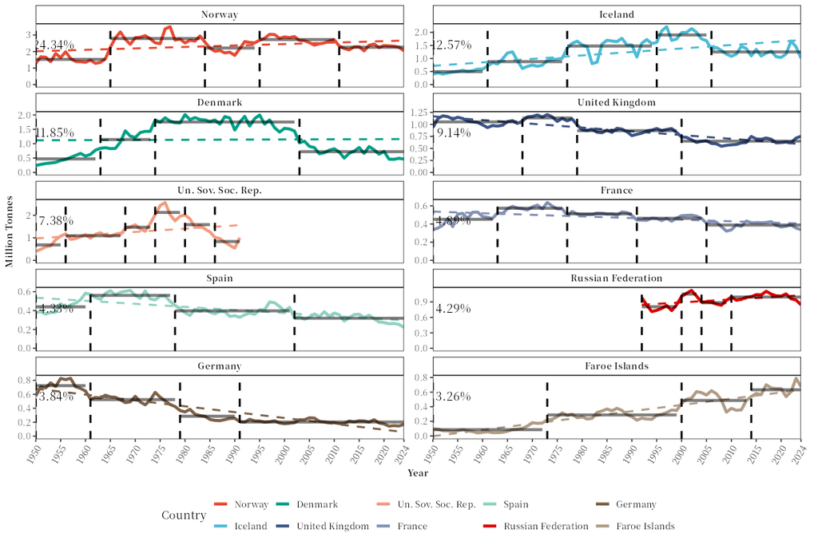

It works like `fishing_area_species()`, by country:

| Output | Content |
| --- | --- |
| `area/area_country.png` | Catch of the selected countries over time |
| `area/area_country_wrap.png` | One panel per country with its share of the area’s catch, a linear trend and the breakpoints (or a smooth curve) |
| `tables/country_ranked_table.csv` | Average catch per decade, catch in each of the last five years, catch and share in the last year |
| `tables/country_coefs_data.csv` | The breakpoints |
| Returned list | `area_country` (catch of every country by year), `area_country_ranked`, `area_country_ranked_total` and `coefs_data` |

```r
show_table(countries$area_country_ranked_total)
```

| Country..Name. | Total_Tonnes | Percentage | Rank_Tonnes |
| --- | --- | --- | --- |
| Norway | 175,537,274 | 24.34 | 175,537,274 |
| Iceland | 90,654,303 | 12.57 | 90,654,303 |
| Denmark | 85,470,967 | 11.85 | 85,470,967 |
| United Kingdom | 65,908,778 | 9.14 | 65,908,778 |
| Un. Sov. Soc. Rep. | 53,248,275 | 7.38 | 53,248,275 |
| France | 35,289,487 | 4.89 | 35,289,487 |
| Spain | 31,240,735 | 4.33 | 31,240,735 |
| Russian Federation | 30,914,334 | 4.29 | 30,914,334 |
| Germany | 27,722,268 | 3.84 | 27,722,268 |
| Faroe Islands | 23,481,732 | 3.26 | 23,481,732 |

All arguments of `fishing_area_country()`. As for the species, the panel chart with breakpoints has fixed line widths, text sizes and two columns.

| Argument | Meaning | Default |
| --- | --- | --- |
| `area_data` | Catch data of an area: `fishing_area_data()$area_data` or any subset of `load_fao_data()` |  |
| `rank_range` | Ranks of the countries shown, by total catch over all years: `1:10` the ten largest, `c(5, 6)` the fifth and the sixth | `1:10` |
| `plot` | Save the charts | `TRUE` |
| `table` | Save the two tables in `tables/` | `TRUE` |
| `timeseries_analysis` | `TRUE`: panel chart with linear trend and breakpoints; `FALSE`: panel chart with a smooth curve | `TRUE` |
| `h_value` | Minimum length of a period between breakpoints: a fraction of the series or a number of years | `0.15` |
| `line_width` | Width of the lines of the time series chart (`area_country.png`) | `1.5` |
| `line_alpha` | Transparency of the lines of the time series chart and of the panel chart without breakpoints | `0.7` |
| `line_linewidth` | Width of the lines of the panel chart without breakpoints | `1.5` |
| `point_size` | Size of the points of the time series chart and of the panel chart without breakpoints | `1.8` |
| `point_alpha` | Transparency of these points | `0.7` |
| `point_shape` | Shape of these points (R point symbol) | `1` |
| `axis_text_size`, `axis_text_face` | Size and font face of the axis labels (time series chart; y axis of the panel chart without breakpoints) | `10`, `"plain"` |
| `axis_title_size`, `axis_title_face` | Size and font face of the axis titles (time series chart; panel chart without breakpoints) | `10`, `"bold"` |
| `strip_text_size`, `strip_text_face` | Size and font face of the panel titles of the panel chart without breakpoints | `10`, `"bold"` |
| `smooth_method` | Smoothing method of the curve in the panel chart without breakpoints, as in `ggplot2::geom_smooth()` | `"loess"` |
| `smooth_linetype` | Line type of that curve | `"dashed"` |
| `text_hjust`, `text_vjust` | Justification of the share label in each panel | `0.9`, `-4` |
| `text_size`, `text_color` | Size and colour of the share label | `4.5`, `"black"` |
| `facet_ncol` | Number of columns of the panel chart without breakpoints | `2` |
| `ZH` | Older way of asking for Chinese: `TRUE` is `lang = "zh"` | `FALSE` |
| `lang` | Language of the chart text and names: `"en"`, `"zh"` or `"both"` | `NULL`: `"zh"` if `ZH = TRUE`, else the language of `fao_settings()` |
| `pptx` | Also save the charts as editable PowerPoint files | `FALSE`, or `pptx` of `fao_settings()` |
| `plot_show` | Also draw each chart in the plot window (e.g. the Plots pane of RStudio) as it is saved | `FALSE`, or `plot_show` of `fao_settings()` |

## 📐 How the breakpoints are found

The breakpoints divide a catch series into periods with different mean catch. Each series is fitted with a model of constant mean (`catch ~ 1`) in each period; the breakpoints that minimise the residual sum of squares are found by dynamic programming (Bai and Perron 2003), and the number of breakpoints is chosen by the Bayesian information criterion (BIC), as done by `strucchange::breakpoints()` (Zeileis et al. 2002, 2003). Every period has at least `h` years: 15% of the series in `fishing_area_data()`, and `h_value` in the other functions.

| Function | Series analysed |
| --- | --- |
| `fishing_area_data()` | Total catch of the area in each year |
| `fishing_area_species()` | Catch of each species, over its longest run of consecutive years |
| `fishing_area_country()` | Catch of each country, over all years with records (a warning is given when years are missing) |

The breakpoints show when the level of the catch changed, not why: changes in fishing, in the stocks, in markets or in reporting can all move the catch.

## 🌏 Another area: the Northwest Atlantic

Any FAO area works the same way. The Northwest Atlantic (area 21) lies off Canada, the United States and Greenland:

```r
FAO21 <- fishing_area_data("Atlantic, Northwest")
fishing_area_country(FAO21$area_data, rank_range = 1:8)
```

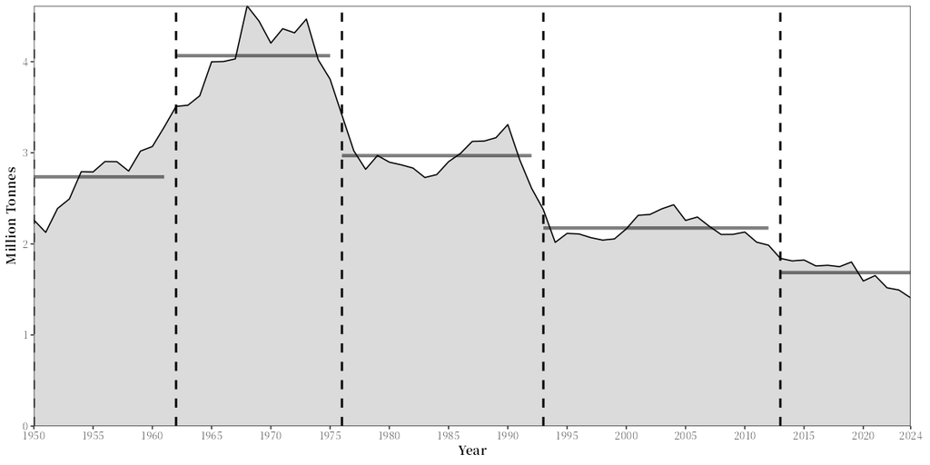

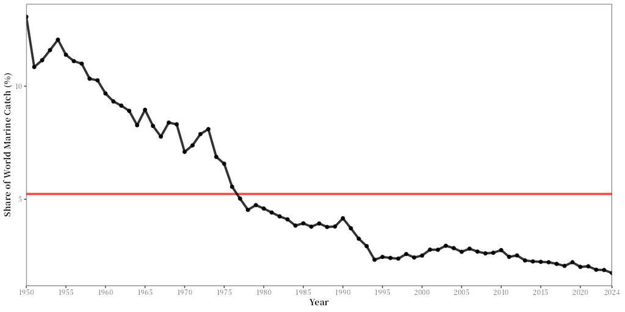

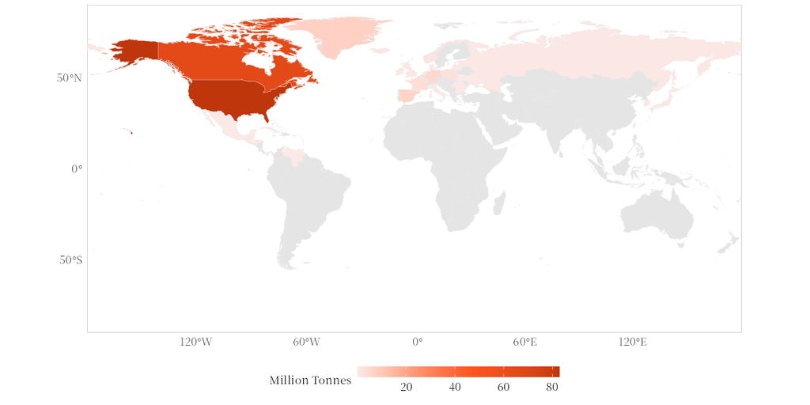

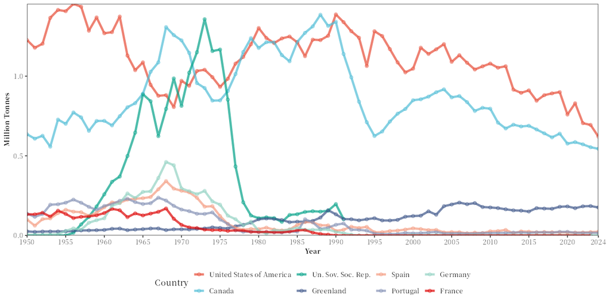

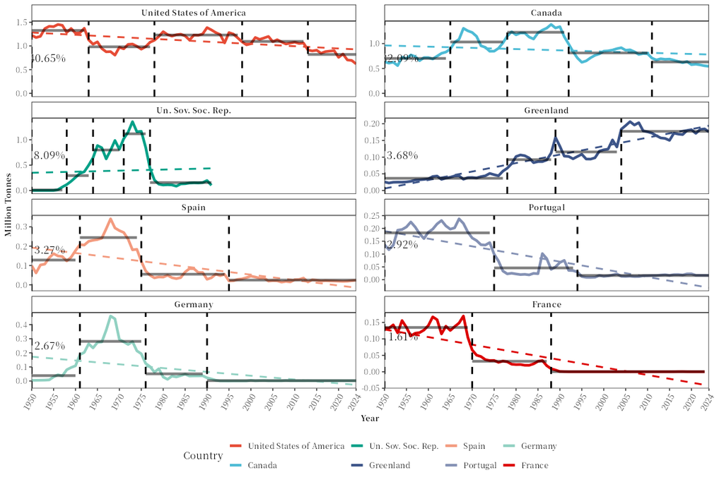

The catch of area 21 was largest in 1968 (4.6 million t) and was 1.4 million t in 2024. Its Atlantic cod fell from 564 thousand t in 1990 to 31 thousand t in 1995: the cod off Newfoundland and Labrador collapsed, and Canada closed the fishery in 1992 (Hutchings and Myers 1994).

Charts of different areas are saved under the same file names (e.g. `fishing_trend.png`), so use one working folder per area, e.g. `setwd("reports/FAO21")`.

## 📖 References

Bai, J. and Perron, P. (2003). Computation and analysis of multiple structural change models. *Journal of Applied Econometrics* 18(1): 1–22. [doi:10.1002/jae.659](https://doi.org/10.1002/jae.659)

CWP (Coordinating Working Party on Fishery Statistics). *CWP Handbook of Fishery Statistics*: Main water areas (FAO major fishing areas). Rome: FAO. https://www.fao.org/cwp-on-fishery-statistics/handbook/general-concepts/main-water-areas/en/

FAO (2026). FishStat: Global capture production 1950–2024 (release 2026.1.0). In: FishStatJ. https://www.fao.org/fishery/statistics/software/fishstatj/en. Licence: CC-BY-4.0. Release file: https://www.fao.org/fishery/static/Data/Capture_2026.1.0.zip

FAO. Fishing area maps. In: FAO Fisheries and Aquaculture Division [online]. Rome. https://www.fao.org/fishery/docs/maps/Default.htm

FAO (2024). FAO Major Fishing Areas for Statistical Purposes. In: FAO Fisheries and Aquaculture Division [online]. Licence: CC-BY 4.0. https://www.fao.org/fishery/geonetwork?uuid=ac02a460-da52-11dc-9d70-0017f293bd28 (the area boundaries of the maps, bundled as `inst/extdata/FAO_AREAS_CWP.shp`)

FAO (2026). *Fishery and Aquaculture Statistics – Yearbook 2024*. FAO Yearbook of Fishery and Aquaculture Statistics. Rome: FAO. [doi:10.4060/ce1217en](https://doi.org/10.4060/ce1217en)

Hutchings, J.A. and Myers, R.A. (1994). What can be learned from the collapse of a renewable resource? Atlantic cod, *Gadus morhua*, of Newfoundland and Labrador. *Canadian Journal of Fisheries and Aquatic Sciences* 51(9): 2126–2146. [doi:10.1139/f94-214](https://doi.org/10.1139/f94-214)

Massicotte, P. and South, A. *rnaturalearth: World Map Data from Natural Earth*. R package. [doi:10.32614/CRAN.package.rnaturalearth](https://doi.org/10.32614/CRAN.package.rnaturalearth)

Natural Earth. Admin 0 – Details, map units, 1:50m (the country outlines of the maps). https://www.naturalearthdata.com/downloads/50m-cultural-vectors/50m-admin-0-details/

NOAA National Centers for Environmental Information (2022). ETOPO 2022 15 Arc-Second Global Relief Model. [doi:10.25921/fd45-gt74](https://doi.org/10.25921/fd45-gt74)

Pebesma, E. (2018). Simple features for R: standardized support for spatial vector data. *The R Journal* 10(1): 439–446. [doi:10.32614/RJ-2018-009](https://doi.org/10.32614/RJ-2018-009)

Vihtakari, M. (2026). *ggOceanMaps: Plot Data on Oceanographic Maps using ‘ggplot2’*. R package version 3.0.0. [doi:10.32614/CRAN.package.ggOceanMaps](https://doi.org/10.32614/CRAN.package.ggOceanMaps). GitHub: https://github.com/MikkoVihtakari/ggOceanMaps

Wickham, H. (2016). *ggplot2: Elegant Graphics for Data Analysis*. New York: Springer. [doi:10.1007/978-3-319-24277-4](https://doi.org/10.1007/978-3-319-24277-4)

Zeileis, A., Kleiber, C., Krämer, W. and Hornik, K. (2003). Testing and dating of structural changes in practice. *Computational Statistics & Data Analysis* 44(1–2): 109–123. doi:10.1016/S0167-9473(03)00030-6

Zeileis, A., Leisch, F., Hornik, K. and Kleiber, C. (2002). strucchange: an R package for testing for structural change in linear regression models. *Journal of Statistical Software* 7(2): 1–38. [doi:10.18637/jss.v007.i02](https://doi.org/10.18637/jss.v007.i02)